# 可用的全等判定

> 來源整理：改國二下6_三角形的全等_易讀版.md

## 五種三角形全等判定總覽

> 學習目標：判定全等不需要全部邊角都知道，只要掌握正確的條件組合即可。

### 先抓住核心

- SSS：三邊對應相等。
- SAS：兩邊和它們的夾角對應相等。
- ASA：兩角和夾邊對應相等。
- AAS：兩角和其中一個對應邊相等。
- RHS：兩個直角三角形的斜邊和一股對應相等，也常稱 HL。
- S 表示邊，A 表示角，R 表示直角，H 表示斜邊。

### 解題流程

1. 先判斷題目給了幾條邊、幾個角。
2. 確認角是不是夾角、邊是不是夾邊。
3. 若是直角三角形，檢查斜邊與一股是否對應相等。
4. 符合五種之一才可寫出三角形全等。

### 公式、性質與判斷

- **SSS**：三邊。
- **SAS**：兩邊夾一角。
- **ASA**：兩角夾一邊。
- **AAS**：兩角與一邊。
- **RHS/HL**：直角三角形：斜邊與一股。

### 例題拆解

- 若已知 AB=DE、BC=EF、AC=DF，可用 SSS。
- 若已知 AB=DE、BC=EF 且 ∠B=∠E，因為 ∠B 是夾角，可用 SAS。
- 若兩個直角三角形斜邊相等且一股相等，可用 RHS。

### 易錯提醒

- 把 SSA 誤認成 SAS。
- RHS 忘記限定在直角三角形。

### 小練一下

- SAS 的 A 必須是哪一種角？
- 兩個直角三角形只知道一個銳角和一股相等，可以直接用 RHS 嗎？

### 記憶鉤子

- 判定全等像看鑰匙齒形：條件組合對了才開得了門。
- 看到兩邊一角時，第一件事是問：這個角是不是夾角？

### 圖像化理解

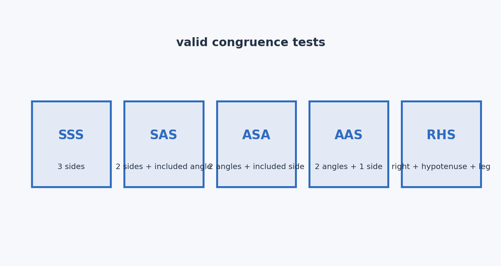

五種三角形全等判定總覽

圖解：把 SSS、SAS、ASA、AAS、RHS 五種判定放成一張判斷卡。

## SSS 與 SAS：邊決定形狀

> 學習目標：SSS 用三邊鎖定三角形；SAS 用兩邊與夾角鎖定三角形。

### 先抓住核心

- SSS 只看三組對應邊是否相等，不需要先知道角。
- SAS 要有兩組對應邊相等，還要有這兩邊中間的夾角相等。
- SAS 的角若不是夾角，就不是 SAS。
- 正方形、正三角形題常能提供相等邊與直角或 60°，因此常用 SAS。
- 證明時要把三個條件逐條列出，再寫出全等結論。

### 解題流程

1. 列出三角形名稱與想證明的對應順序。
2. 若有三邊相等，使用 SSS。
3. 若有兩邊一角，檢查角是否夾在兩邊之間。
4. 確認後寫：所以兩三角形全等。

### 公式、性質與判斷

- **SSS**：三組對應邊相等。
- **SAS**：兩組對應邊 + 夾角相等。
- **SAS 檢查**：角必須夾在兩條已知邊之間。

### 例題拆解

- 正三角形 ABC 中，AB=BC；若又有 BD=CE 且 ∠ABD=∠BCE，可用 SAS 證 △ABD ≅ △BCE。
- 兩個正方形共用頂點時，正方形邊相等、角為 90°，常能組出 SAS。
- 只知道兩邊和一個非夾角時，不能直接說 SAS。

### 易錯提醒

- 看到兩邊一角就急著寫 SAS，沒有檢查夾角。
- 證明全等時只寫結論，沒有列出對應條件。

### 小練一下

- 三邊對應相等用哪一種全等？
- 兩邊和一角相等一定是 SAS 嗎？

### 記憶鉤子

- SAS 的 A 要被兩個 S 夾住。
- SSS 是最直覺的鎖形狀方式：三邊一固定，三角形就固定。

### 圖像化理解

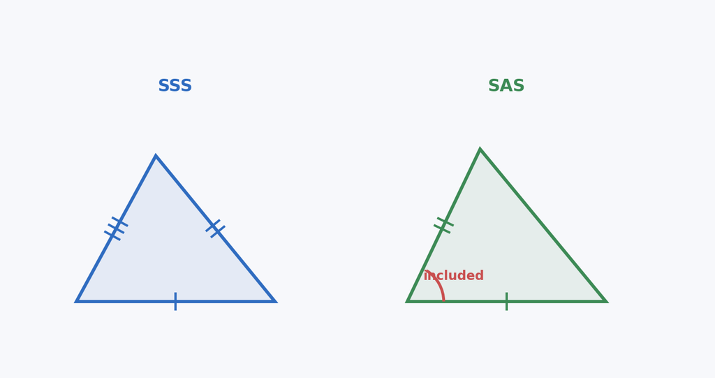

SSS 與 SAS：邊決定形狀

圖解：用兩張小圖比較 SSS 三邊鎖定與 SAS 夾角鎖定。

## ASA 與 AAS：角搭配一邊

> 學習目標：兩個角已知時，三角形形狀已接近固定，再加一條對應邊就能決定大小。

### 先抓住核心

- ASA 是兩角與夾在兩角中間的邊對應相等。
- AAS 是兩角與其中一個對應邊相等，這條邊不一定是夾邊。
- 知道兩角後，第三角可由 180° 減掉前兩角求得。
- 所以 AAS 常可轉成 ASA 來理解。
- 折疊與平行線題常提供相等角，因此容易用 ASA 或 AAS。

### 解題流程

1. 先找兩組相等角。
2. 確認已知邊是夾邊還是非夾邊。
3. 夾邊相等可用 ASA。
4. 非夾邊相等可用 AAS，或先求第三角再轉成 ASA。

### 公式、性質與判斷

- **ASA**：兩角 + 夾邊。
- **AAS**：兩角 + 一邊。
- **第三角**：第三角 = 180° - 兩已知角。

### 例題拆解

- 若 ∠B=∠E、BC=EF、∠C=∠F，可用 ASA。
- 若 ∠A=∠D、∠B=∠E、BC=EF，可用 AAS。
- 正方形靠牆題中，若能找到兩角相等與一邊相等，就可用 AAS。

### 易錯提醒

- 把非夾邊當夾邊，ASA/AAS 名稱寫錯。
- 忘記兩角已知時第三角也被決定。

### 小練一下

- ASA 和 AAS 的差別在哪一個字？
- 已知兩角時，第三角能不能求出？

### 記憶鉤子

- ASA 是角-邊-角，邊被夾在兩角中間。
- AAS 可先補第三角，常能轉成 ASA 的感覺。

### 圖像化理解

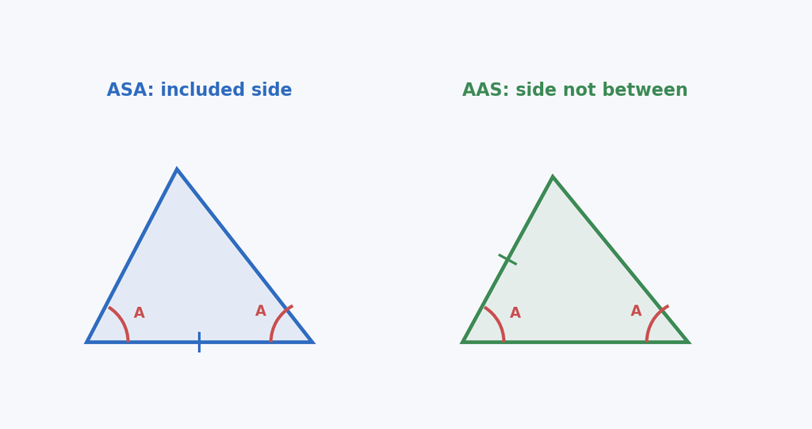

ASA 與 AAS：角搭配一邊

圖解：比較 ASA 的夾邊與 AAS 的非夾邊，避免名稱混淆。

## RHS：直角三角形的斜邊與一股

> 學習目標：RHS 是直角三角形專用判定，重點是直角、斜邊、一股。

### 先抓住核心

- RHS 只適用於直角三角形。
- R 代表直角，H 代表斜邊，S 代表一股。
- 若兩個直角三角形斜邊對應相等，且一股對應相等，則兩三角形全等。
- RHS 也常稱 HL，全名是 hypotenuse-leg。
- 使用前要先確認哪一條是斜邊：直角對面的邊才是斜邊。

### 解題流程

1. 先確認兩個三角形都有直角。
2. 找出兩個三角形的斜邊。
3. 確認斜邊對應相等。
4. 再確認一組股對應相等。
5. 符合後可用 RHS 判定全等。

### 公式、性質與判斷

- **RHS/HL**：直角 + 斜邊 + 一股。
- **斜邊**：直角對面的邊。

### 例題拆解

- 若兩個直角三角形的斜邊都為 13，一股都為 5，則可用 RHS。
- 若只知道兩個直角三角形各有一個銳角相等，還不能用 RHS。
- 摺疊或垂直題常會產生直角，可先檢查 RHS 是否能用。

### 易錯提醒

- 沒有直角卻套 RHS。
- 把直角旁邊的邊誤當成斜邊。

### 小練一下

- RHS 可以用在非直角三角形嗎？
- 直角三角形的斜邊是哪一邊？

### 記憶鉤子

- RHS 的第一步永遠是確認直角。
- 斜邊不是看起來最長而已，它必須是直角對邊。

### 圖像化理解

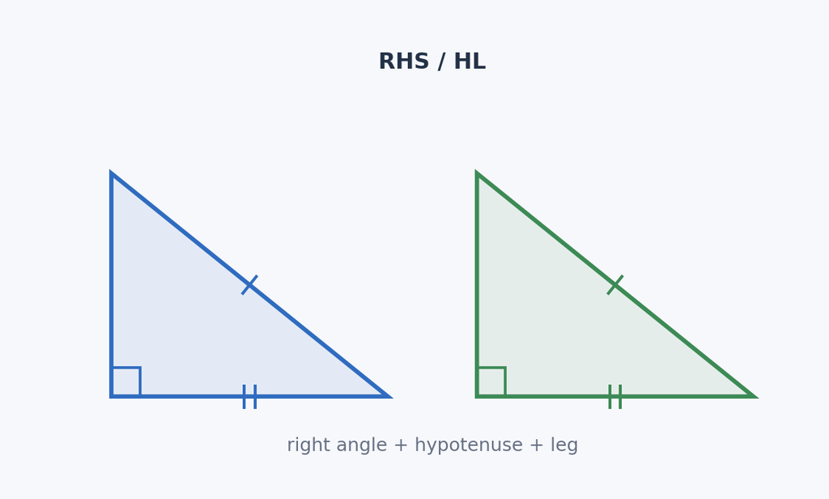

RHS：直角三角形的斜邊與一股

圖解：標出直角三角形的斜邊與一股，說明 RHS 條件。